# Assignment 4: Predictive Policing & Analysis

# Part 3: Create a Kernel Density Estimate (KDE) Baseline

- KDE represents our *null hypothesis*: burglaries happen where they happened before, with no other information
- In this context, KDE involves centering a smooth kernel, or curve, atop each crime point such that the curve is at its highest directly over the point and the lowest at the range of a circular *search radius* parameter (commonly known as *kernel density* in ArcGIS)

```r
# Convert burglaries to ppp (point pattern) format for spatstat
burglaries_ppp <- as.ppp(
  st_coordinates(burglaries),
  W = as.owin(st_bbox(chicagoBoundary))
)

# Calculate KDE with 1km bandwidth
kde_burglaries <- density.ppp(
  burglaries_ppp,
  sigma = 1000,  # 1km bandwidth
  edge = TRUE    # Edge correction
)

# Convert to terra raster
kde_raster <- rast(kde_burglaries)

# Extract KDE values to fishnet cells
fishnet <- fishnet %>%
  mutate(
    kde_value = terra::extract(
      kde_raster,
      vect(fishnet),
      fun = mean,
      na.rm = TRUE
    )[, 2]  # Extract just the values column
  )

cat("✓ Calculated KDE baseline\n")
```

```
✓ Calculated KDE baseline
```

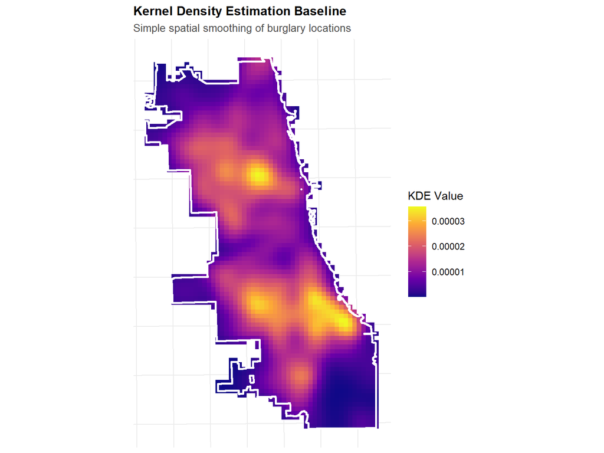

```r
ggplot() +
  geom_sf(data = fishnet, aes(fill = kde_value), color = NA) +
  geom_sf(data = chicagoBoundary, fill = NA, color = "white", linewidth = 1) +
  scale_fill_viridis_c(
    name = "KDE Value",
    option = "plasma"
  ) +
  labs(
    title = "Kernel Density Estimation Baseline",
    subtitle = "Simple spatial smoothing of burglary locations"
  ) +
  theme_crime()
```

# Part 4: Create Spatial Predictor Variables

Now we’ll create features that might help predict burglaries. We’ll use “broken windows theory” logic: signs of disorder predict crime. In this lab report, I specifically focus on 311 calls to report *vacant and abandoned buildings*. The data source is the Chicago 311 Service Requests dataset which I accessed through https://data.cityofchicago.org/stories/s/311-Dataset-Changes-12-11-2018/d7nq-5g7t

In this section, I first load, filter and clean the “Vacant and Abandoned Buildings Reported” dataset. While this preliminary report does not look at specific columns, there are variables such as `vacant_due_to_fire` or `ppl_using_prop` that could potentially be applied to a more complex random forest model in order to better predict crime risk.

Next, I calculate different spatial measures that each capture an aspect of spatial proximity to our indicator variable of burglary risk.

- Count → How much disorder is HERE?
- k-NN Distance → How CLOSE are we to disorder?
- Hot Spots (LISA) → Where does disorder CLUSTER?
- Distance to Hot Spots → How close to concentrated disorder?

### 4.1 | Load 311 Vacant and Abandoned Buildings Reported

```r
vacant_abandoned_bldg <- read_csv("data/vacant_abandoned_buildings.csv") |>
  filter(!is.na(LATITUDE), !is.na(LONGITUDE))
```

```r
# clean and rename column names
vacant_abandoned_bldg_2017 <- vacant_abandoned_bldg |>
  janitor::clean_names() |>
  rename(
    request_type           = service_request_type,
    request_num            = service_request_number,
    date_received          = date_service_request_was_received,
    location_on_lot        =
      location_of_building_on_the_lot_if_garage_change_type_code_to_bgd,
    dangerous_hazardous    = is_the_building_dangerous_or_hazardous,
    open_or_boarded        = is_building_open_or_boarded,
    entry_point            = if_the_building_is_open_where_is_the_entry_point,
    vacant_or_occupied     = is_the_building_currently_vacant_or_occupied,
    vacant_due_to_fire     = is_the_building_vacant_due_to_fire,
    # note typo in original dataset - childen instead of children
    ppl_using_prop         = any_people_using_property_homeless_childen_gangs,
    addr_st_num            = address_street_number,
    addr_st_direction      = address_street_direction,
    addr_st_name           = address_street_name,
    addr_st_suffix         = address_street_suffix,
    zip                    = zip_code,
    x                      = x_coordinate,
    y                      = y_coordinate,
    ward                   = ward,
    police_dist            = police_district,
    community_area         = community_area,
    lat                    = latitude,
    lon                    = longitude,
    location               = location
  ) |>
   # filter vacant and abandoned buildings reported in 2017
  mutate(
    date_received = as.Date(date_received, format = "%m/%d/%Y"),
    month = as.integer(format(date_received, "%m")),
    day   = as.integer(format(date_received, "%d")),
    year  = as.integer(format(date_received, "%Y"))
  ) |>
  filter(year == 2017)
```

```r
# filter NA values and select relevant columns
vacant_abandoned_bldg_2017 <- vacant_abandoned_bldg_2017 |>
  dplyr::mutate(
    addr_full = str_squish( # combine address variables
      paste(addr_st_num, addr_st_direction, addr_st_name, addr_st_suffix))
  )

keep_cols <- c(
  "request_num","year","month", "open_or_boarded","vacant_or_occupied",
  "vacant_due_to_fire","ppl_using_prop", "addr_full", "zip","x","y","ward",
  "police_dist","community_area","lat","lon","location")

vacant_abandoned_bldg_2017 <- vacant_abandoned_bldg_2017 |>
  dplyr::select(any_of(keep_cols)) |>
  dplyr::filter(!is.na(vacant_or_occupied))

vacant_abandoned_bldg_2017
```

```
# A tibble: 3,147 × 17
   request_num  year month open_or_boarded vacant_or_occupied vacant_due_to_fire
   <chr>       <int> <int> <chr>           <chr>              <lgl>
 1 17-08691267  2017    12 Open            Vacant             FALSE
 2 17-08681436  2017    12 Open            Vacant             FALSE
 3 17-08682637  2017    12 Boarded         Vacant             FALSE
 4 17-08663198  2017    12 Open            Vacant             FALSE
 5 17-08663448  2017    12 Open            Vacant             FALSE
 6 17-08656967  2017    12 Boarded         Vacant             FALSE
 7 17-08674767  2017    12 Open            Vacant             FALSE
 8 17-08659803  2017    12 Open            Vacant             FALSE
 9 17-08638267  2017    12 Open            Vacant             FALSE
10 17-08642801  2017    12 Open            Vacant             FALSE
# ℹ 3,137 more rows
# ℹ 11 more variables: ppl_using_prop <lgl>, addr_full <chr>, zip <dbl>,
#   x <dbl>, y <dbl>, ward <dbl>, police_dist <dbl>, community_area <dbl>,
#   lat <dbl>, lon <dbl>, location <chr>
```

```r
# Set CRS
abandoned_bldg <- vacant_abandoned_bldg_2017 |>
  st_as_sf(coords = c("lon", "lat"), crs = 4326) |>
  st_transform('ESRI:102271') # Set CRS

cat("✓ Loaded vacant/abandoned building calls\n")
```

```
✓ Loaded vacant/abandoned building calls
```

```r
cat("  - Number of calls:", nrow(vacant_abandoned_bldg_2017), "\n")
```

```
  - Number of calls: 3147
```

**NoteNote of Caution**

- The 311 reporting system in Chicago may be biased because it relies on residents to voluntarily report issues, meaning that neighborhoods with higher civic engagement or stronger trust in city services are more likely to generate reports.
- As a result, 311 data in Chicago may underrepresent conditions in lower-income or marginalized communities, where residents may be less aware of or less inclined to call the hotline.

### 4.2 | Count of Reported Vacant/Abandoned Buildings per Cell

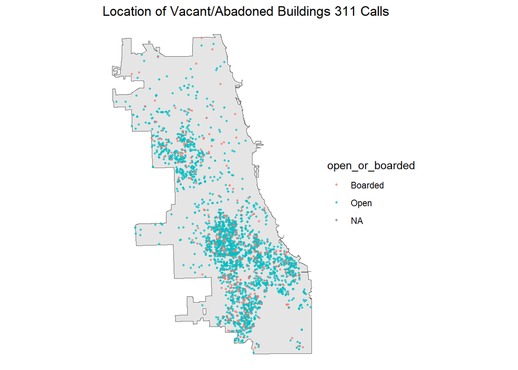

```r
# Gut Check Visualization of Vacant/Abandoned Buildings
ggplot() +
  geom_sf(data = chicagoBoundary) +
  geom_sf(data = abandoned_bldg, aes(color = open_or_boarded),
          alpha = 0.7, size = 0.7) +
  labs(title = "Location of Vacant/Abadoned Buildings 311 Calls") +
  theme_void()
```

```r
# Aggregate abandoned building calls to fishnet
abandoned_fishnet <- st_join(abandoned_bldg, fishnet,
                             join = st_within) %>%
  st_drop_geometry() %>%
  group_by(uniqueID) %>%
  summarize(abandoned_bldg = n())

# Join to fishnet
fishnet <- fishnet %>%
  left_join(abandoned_fishnet, by = "uniqueID") %>%
  mutate(abandoned_bldg = replace_na(abandoned_bldg, 0))

cat("Vacant and Abandoned Building distribution:\n")
```

```
Vacant and Abandoned Building distribution:
```

```r
summary(fishnet$abandoned_bldg)
```

```
   Min. 1st Qu.  Median    Mean 3rd Qu.    Max.
   0.00    0.00    0.00    1.28    1.00   21.00
```

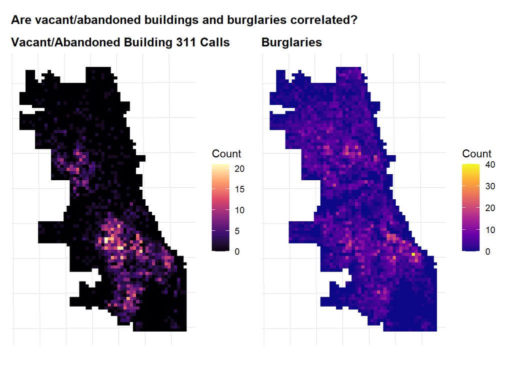

```r
p1 <- ggplot() +
  geom_sf(data = fishnet, aes(fill = abandoned_bldg), color = NA) +
  scale_fill_viridis_c(name = "Count", option = "magma") +
  labs(title = "Vacant/Abandoned Building 311 Calls") +
  theme_crime()

p2 <- ggplot() +
  geom_sf(data = fishnet, aes(fill = countBurglaries), color = NA) +
  scale_fill_viridis_c(name = "Count", option = "plasma") +
  labs(title = "Burglaries") +
  theme_crime()

p1 + p2 +
  plot_annotation(
    title = "Are vacant/abandoned buildings and burglaries correlated?")
```

### 4.3 | k-Nearest Neighbors (kNN) Features

Count in a cell is one measure. Distance to the 5 nearest vacant and abandoed buildings that were reported through 311 calls captures additional local context that are not just limited to administrative boundaries such as census tracts.

```r
# Calculate mean distance to 5 nearest vacant and abandoned buildings
# (Do this OUTSIDE of mutate to avoid sf conflicts)

# Get coordinates
fishnet_coords <- st_coordinates(st_centroid(fishnet))
abandoned_coords <- st_coordinates(abandoned_bldg)

# Calculate k nearest neighbors and distances
nn_result <- get.knnx(abandoned_coords, fishnet_coords, k = 5)

# Add to fishnet
fishnet <- fishnet %>%
  mutate(
    abandoned_bldg.nn = rowMeans(nn_result$nn.dist)
  )

cat("✓ Calculated nearest neighbor distances\n")
```

```
✓ Calculated nearest neighbor distances
```

```r
summary(fishnet$abandoned_bldg.nn)
```

```
   Min. 1st Qu.  Median    Mean 3rd Qu.    Max.
  29.95  386.48  848.67 1011.75 1431.03 5313.74
```

### 4.4 | Local Moran’s I; Identify Hotspots; Distance to Hot Spots

Let’s identify clusters of abandoned buildings using Local Moran’s I, then calculate distance to these hot spots.

```r
# Function to calculate Local Moran's I
calculate_local_morans <- function(data, variable, k = 5) {

  # Create spatial weights
  coords <- st_coordinates(st_centroid(data))
  neighbors <- knn2nb(knearneigh(coords, k = k))
  weights <- nb2listw(neighbors, style = "W", zero.policy = TRUE)

  # Calculate Local Moran's I
  local_moran <- localmoran(data[[variable]], weights)

  # Classify clusters
  mean_val <- mean(data[[variable]], na.rm = TRUE)

  data %>%
    mutate(
      local_i = local_moran[, 1],
      p_value = local_moran[, 5],
      is_significant = p_value < 0.05,

      moran_class = case_when(
        !is_significant ~ "Not Significant",
        local_i > 0 & .data[[variable]] > mean_val ~ "High-High",
        local_i > 0 & .data[[variable]] <= mean_val ~ "Low-Low",
        local_i < 0 & .data[[variable]] > mean_val ~ "High-Low",
        local_i < 0 & .data[[variable]] <= mean_val ~ "Low-High",
        TRUE ~ "Not Significant"
      )
    )
}

# Apply to vacant and abandoned buildings
fishnet <- calculate_local_morans(fishnet, "abandoned_bldg", k = 5)
```

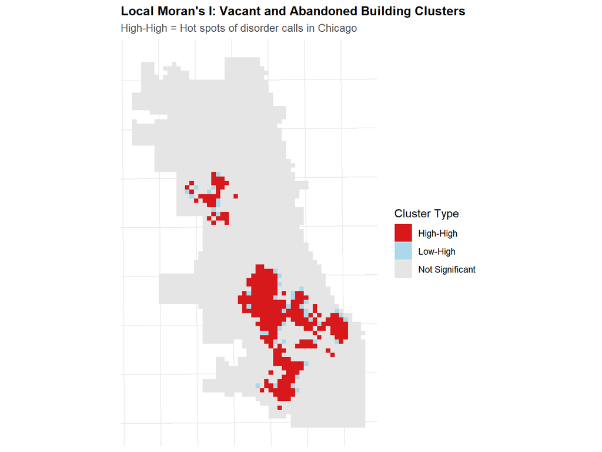

```r
# Visualize hot spots
ggplot() +
  geom_sf(
    data = fishnet,
    aes(fill = moran_class),
    color = NA
  ) +
  scale_fill_manual(
    values = c(
      "High-High" = "#d7191c",
      "High-Low" = "#fdae61",
      "Low-High" = "#abd9e9",
      "Low-Low" = "#2c7bb6",
      "Not Significant" = "gray90"
    ),
    name = "Cluster Type"
  ) +
  labs(
    title = "Local Moran's I: Vacant and Abandoned Building Clusters",
    subtitle = "High-High = Hot spots of disorder calls in Chicago"
  ) +
  theme_crime()
```

```r
# Get centroids of "High-High" cells (hot spots)
hotspots <- fishnet %>%
  filter(moran_class == "High-High") %>%
  st_centroid()

# Calculate distance from each cell to nearest hot spot
if (nrow(hotspots) > 0) {
  fishnet <- fishnet %>%
    mutate(
      dist_to_hotspot = as.numeric(
        st_distance(st_centroid(fishnet), hotspots %>% st_union())
      )
    )

  cat("✓ Calculated distance to vacant and abandoned building hot spots\n")
  cat("  - Number of hot spot cells:", nrow(hotspots), "\n")
} else {
  fishnet <- fishnet %>%
    mutate(dist_to_hotspot = 0)
  cat("⚠ No significant hot spots found\n")
}
```

```
✓ Calculated distance to vacant and abandoned building hot spots
  - Number of hot spot cells: 272
```

**NoteObserved Patterns**

- **Distribution of Vacant/Abandoned Building 311 Calls:** The majority of reported properties are open rather than boarded, while boarded properties are relatively sparse and scattered
- **Count of Vacant/Abandoned Building 311 Calls:** The distribution is highly skewed, with most grid cells containing zero or one vacant property. Notably, the median value is 0 while the max value is 21. This indicates the presence of a few extreme hotspots of concentrated vacancy which is supported by the subsequent map visualizations.
- **Map of Vacant/Abandoned Building 311 Calls and Burglaries:** 311 calls for vacant buildings (left panel) are especially dense in a few concentrated areas, while burglary counts (right panel) are more spatially dispersed but still overlap with several high-vacancy zones
- **Local Moran’s I:** High–High hotspot clusters (in red) indicate statistically significant concentrations of vacant or abandoned buildings, primarily located on the South and West Sides of Chicago

# Part 5: Join Police Districts for Cross-Validation

We’ll use the Chicago police districts for our spatial cross-validation.

```r
# Join district information to fishnet
fishnet <- st_join(
  fishnet,
  policeDistricts,
  join = st_within,
  left = TRUE
) %>%
  filter(!is.na(District))  # Remove cells outside districts

cat("✓ Joined police districts\n")
```

```
✓ Joined police districts
```

```r
cat("  - Districts:", length(unique(fishnet$District)), "\n")
```

```
  - Districts: 22
```

```r
cat("  - Cells:", nrow(fishnet), "\n")
```

```
  - Cells: 1708
```

# Part 6: Count Regression Model Fitting

### 6.1 | Poisson Regression

Poisson regression is used instead of OLS because crime counts are right-skewed with many zeroes (around 30% of fishnet cells have no burglaries in 2017) and also discrete (only integer values). This makes Poisson regression suitable for count data.

```r
# Create clean modeling dataset
fishnet_model <- fishnet %>%
  st_drop_geometry() %>%
  dplyr::select(
    uniqueID,
    District,
    countBurglaries,
    abandoned_bldg,
    abandoned_bldg.nn,
    dist_to_hotspot
  ) %>%
  na.omit()  # Remove any remaining NAs

cat("✓ Prepared modeling data\n")
```

```
✓ Prepared modeling data
```

```r
cat("  - Observations:", nrow(fishnet_model), "\n")
```

```
  - Observations: 1708
```

```r
cat("  - Variables:", ncol(fishnet_model), "\n")
```

```
  - Variables: 6
```

```r
# Fit Poisson regression
model_poisson <- glm(
  countBurglaries ~ abandoned_bldg + abandoned_bldg.nn +
    dist_to_hotspot,
  data = fishnet_model,
  family = "poisson"
)

# Summary
summary(model_poisson)
```

```
Call:
glm(formula = countBurglaries ~ abandoned_bldg + abandoned_bldg.nn +
    dist_to_hotspot, family = "poisson", data = fishnet_model)

Coefficients:
                     Estimate  Std. Error z value             Pr(>|z|)
(Intercept)        1.68028245  0.03010148  55.821 < 0.0000000000000002 ***
abandoned_bldg     0.04345861  0.00397702  10.927 < 0.0000000000000002 ***
abandoned_bldg.nn -0.00081740  0.00004497 -18.177 < 0.0000000000000002 ***
dist_to_hotspot    0.00002829  0.00000713   3.968            0.0000726 ***
---
Signif. codes:  0 '***' 0.001 '**' 0.01 '*' 0.05 '.' 0.1 ' ' 1

(Dispersion parameter for poisson family taken to be 1)

    Null deviance: 6710.3  on 1707  degrees of freedom
Residual deviance: 5334.6  on 1704  degrees of freedom
AIC: 9403

Number of Fisher Scoring iterations: 6
```

### 6.2 | Check for Overdispersion

- Poisson regression assumes variance = mean
- But in reality, real crime count data often violates this assumption because variance is significantly greater than the mean (i.e. overdispersion)

```r
# Calculate dispersion parameter
dispersion <- sum(residuals(model_poisson, type = "pearson")^2) /
              model_poisson$df.residual

cat("Dispersion parameter:", round(dispersion, 2), "\n")
```

```
Dispersion parameter: 3.38
```

```r
cat("Rule of thumb: >1.5 suggests overdispersion\n")
```

```
Rule of thumb: >1.5 suggests overdispersion
```

```r
if (dispersion > 1.5) {
  cat("⚠ Overdispersion detected! Consider Negative Binomial model.\n")
} else {
  cat("✓ Dispersion looks okay for Poisson model.\n")
}
```

```
⚠ Overdispersion detected! Consider Negative Binomial model.
```

### 6.3 | Negative Binomial Regression

Since overdispersion has been detected, we use Negative Binomial regression instead which is more flexible than Poisson Regression because it relaxes the variance = mean assumption

```r
# Fit Negative Binomial model
model_nb <- glm.nb(
  countBurglaries ~ abandoned_bldg + abandoned_bldg.nn +
    dist_to_hotspot,
  data = fishnet_model
)
summary(model_nb)
```

```
Call:
glm.nb(formula = countBurglaries ~ abandoned_bldg + abandoned_bldg.nn +
    dist_to_hotspot, data = fishnet_model, init.theta = 1.419813092,
    link = log)

Coefficients:
                     Estimate  Std. Error z value             Pr(>|z|)
(Intercept)        1.66189112  0.05722613  29.041 < 0.0000000000000002 ***
abandoned_bldg     0.04931960  0.00936161   5.268          0.000000138 ***
abandoned_bldg.nn -0.00088040  0.00007166 -12.285 < 0.0000000000000002 ***
dist_to_hotspot    0.00004581  0.00001194   3.837             0.000124 ***
---
Signif. codes:  0 '***' 0.001 '**' 0.01 '*' 0.05 '.' 0.1 ' ' 1

(Dispersion parameter for Negative Binomial(1.4198) family taken to be 1)

    Null deviance: 2374.4  on 1707  degrees of freedom
Residual deviance: 1957.2  on 1704  degrees of freedom
AIC: 7803.4

Number of Fisher Scoring iterations: 1

              Theta:  1.4198
          Std. Err.:  0.0799

 2 x log-likelihood:  -7793.3700
```

### 6.4 | Compare Model Fit (AIC)

```r
# Compare AIC (lower is better)
cat("\nModel Comparison:\n")
```

```
Model Comparison:
```

```r
cat("Poisson AIC:", round(AIC(model_poisson), 1), "\n")
```

```
Poisson AIC: 9403
```

```r
cat("Negative Binomial AIC:", round(AIC(model_nb), 1), "\n")
```

```
Negative Binomial AIC: 7803.4
```

**NoteOptimal Model Fit**

As expected, due to overdispersion, negative binomial regression has a lower AIC than poisson regression and provides a more suitable model fit for the underlying crime dataset.

# Part 7: Spatial LOGO-CV for 2017 Data

- Leave-One-Group-Out (LOGO) Cross-Validation trains on all districts except one, then tests on the held-out district.
- LOGO-CV is used here instead of k-fold CV or a validation set approach in order to prevent spatial leakage.

```r
# Get unique districts
districts <- unique(fishnet_model$District)
cv_results <- tibble()

cat("Running LOGO Cross-Validation...\n")
```

```
Running LOGO Cross-Validation...
```

```r
for (i in seq_along(districts)) {
  test_district <- districts[i]

  # Split data
  train_data <- fishnet_model %>% filter(District != test_district)
  test_data <- fishnet_model %>% filter(District == test_district)

  # Fit model on training data
  model_cv <- glm.nb(
    countBurglaries ~ abandoned_bldg + abandoned_bldg.nn +
      dist_to_hotspot,
    data = train_data
  )

  # Predict on test data
  test_data <- test_data %>%
    mutate(
      prediction = predict(model_cv, test_data, type = "response")
    )

  # Calculate metrics
  mae <- mean(abs(test_data$countBurglaries - test_data$prediction))
  rmse <- sqrt(mean((test_data$countBurglaries - test_data$prediction)^2))

  # Store results
  cv_results <- bind_rows(
    cv_results,
    tibble(
      fold = i,
      test_district = test_district,
      n_test = nrow(test_data),
      mae = mae,
      rmse = rmse
    )
  )

  cat("  Fold", i, "/", length(districts), "- District", test_district,
      "- MAE:", round(mae, 2), "\n")
}
```

```
  Fold 1 / 22 - District 5 - MAE: 2.6
  Fold 2 / 22 - District 4 - MAE: 2.87
  Fold 3 / 22 - District 22 - MAE: 2.1
  Fold 4 / 22 - District 6 - MAE: 2.99
  Fold 5 / 22 - District 8 - MAE: 2.51
  Fold 6 / 22 - District 7 - MAE: 3.57
  Fold 7 / 22 - District 3 - MAE: 5.54
  Fold 8 / 22 - District 2 - MAE: 2.77
  Fold 9 / 22 - District 9 - MAE: 2.54
  Fold 10 / 22 - District 10 - MAE: 2.14
  Fold 11 / 22 - District 1 - MAE: 2.41
  Fold 12 / 22 - District 12 - MAE: 3.63
  Fold 13 / 22 - District 15 - MAE: 2.26
  Fold 14 / 22 - District 11 - MAE: 3.03
  Fold 15 / 22 - District 18 - MAE: 2.45
  Fold 16 / 22 - District 25 - MAE: 2.63
  Fold 17 / 22 - District 14 - MAE: 3.45
  Fold 18 / 22 - District 19 - MAE: 2.36
  Fold 19 / 22 - District 16 - MAE: 1.83
  Fold 20 / 22 - District 17 - MAE: 1.75
  Fold 21 / 22 - District 20 - MAE: 1.58
  Fold 22 / 22 - District 24 - MAE: 2.13
```

```r
# Overall results
cat("\n✓ Cross-Validation Complete\n")
```

```
✓ Cross-Validation Complete
```

```r
cat("Mean MAE:", round(mean(cv_results$mae), 2), "\n")
```

```
Mean MAE: 2.69
```

```r
cat("Mean RMSE:", round(mean(cv_results$rmse), 2), "\n")
```

```
Mean RMSE: 3.52
```

```r
# Show results
cv_results %>%
  arrange(desc(mae)) %>%
  kable(
    digits = 2,
    caption = "LOGO CV Results by District"
  ) %>%
  kable_styling(bootstrap_options = c("striped", "hover"))
```

LOGO CV Results by District

| fold | test_district | n_test | mae | rmse |
| --- | --- | --- | --- | --- |
| 7 | 3 | 43 | 5.54 | 7.24 |
| 12 | 12 | 73 | 3.63 | 5.08 |
| 6 | 7 | 52 | 3.57 | 4.41 |
| 17 | 14 | 46 | 3.45 | 4.93 |
| 14 | 11 | 43 | 3.03 | 3.43 |
| 4 | 6 | 63 | 2.99 | 4.16 |
| 2 | 4 | 235 | 2.87 | 3.92 |
| 8 | 2 | 56 | 2.77 | 3.47 |
| 16 | 25 | 85 | 2.63 | 3.67 |
| 1 | 5 | 98 | 2.60 | 2.97 |
| 9 | 9 | 107 | 2.54 | 2.97 |
| 5 | 8 | 197 | 2.51 | 3.55 |
| 15 | 18 | 30 | 2.45 | 4.15 |
| 11 | 1 | 28 | 2.41 | 3.06 |
| 18 | 19 | 63 | 2.36 | 3.07 |
| 13 | 15 | 32 | 2.26 | 2.81 |
| 10 | 10 | 63 | 2.14 | 2.80 |
| 22 | 24 | 41 | 2.13 | 3.13 |
| 3 | 22 | 112 | 2.10 | 2.66 |
| 19 | 16 | 129 | 1.83 | 2.11 |
| 20 | 17 | 82 | 1.75 | 2.11 |
| 21 | 20 | 30 | 1.58 | 1.85 |

# Part 8: Model Predictions and Comparison

### 8.1 | Generate Final Predictions

```r
# Fit final model on all data
final_model <- glm.nb(
  countBurglaries ~ abandoned_bldg + abandoned_bldg.nn +
    dist_to_hotspot,
  data = fishnet_model
)

# Add predictions back to fishnet
fishnet <- fishnet %>%
  mutate(
    prediction_nb = predict(final_model, fishnet_model, type = "response")[match(uniqueID, fishnet_model$uniqueID)]
  )

# Also add KDE predictions (normalize to same scale as counts)
kde_sum <- sum(fishnet$kde_value, na.rm = TRUE)
count_sum <- sum(fishnet$countBurglaries, na.rm = TRUE)
fishnet <- fishnet %>%
  mutate(
    prediction_kde = (kde_value / kde_sum) * count_sum
  )
```

### 8.2 | Compare Model vs. KDE Baseline

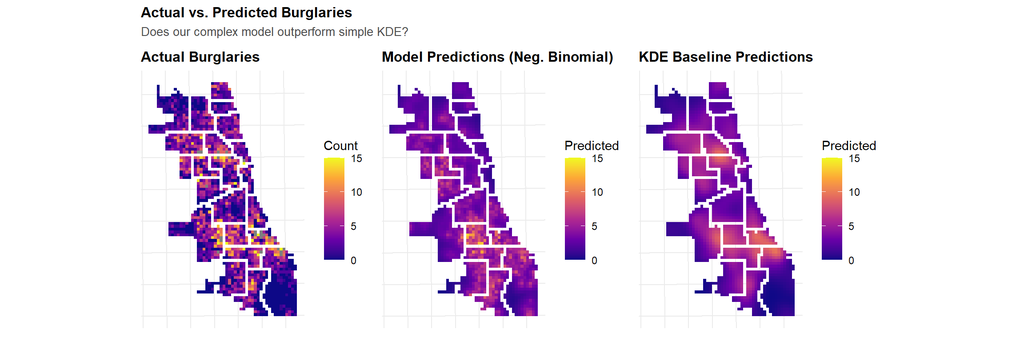

```r
# Create three maps for comparison of Models
p1 <- ggplot() +
  geom_sf(data = fishnet, aes(fill = countBurglaries), color = NA) +
  scale_fill_viridis_c(name = "Count", option = "plasma", limits = c(0, 15)) +
  labs(title = "Actual Burglaries") +
  theme_crime()

p2 <- ggplot() +
  geom_sf(data = fishnet, aes(fill = prediction_nb), color = NA) +
  scale_fill_viridis_c(name = "Predicted", option = "plasma", limits = c(0, 15)) +
  labs(title = "Model Predictions (Neg. Binomial)") +
  theme_crime()

p3 <- ggplot() +
  geom_sf(data = fishnet, aes(fill = prediction_kde), color = NA) +
  scale_fill_viridis_c(name = "Predicted", option = "plasma", limits = c(0, 15)) +
  labs(title = "KDE Baseline Predictions") +
  theme_crime()

p1 + p2 + p3 +
  plot_annotation(
    title = "Actual vs. Predicted Burglaries",
    subtitle = "Does our complex model outperform simple KDE?"
  )
```

```r
# Calculate performance metrics
comparison <- fishnet %>%
  st_drop_geometry() %>%
  filter(!is.na(prediction_nb), !is.na(prediction_kde)) %>%
  summarize(
    model_mae = mean(abs(countBurglaries - prediction_nb)),
    model_rmse = sqrt(mean((countBurglaries - prediction_nb)^2)),
    kde_mae = mean(abs(countBurglaries - prediction_kde)),
    kde_rmse = sqrt(mean((countBurglaries - prediction_kde)^2))
  )

comparison %>%
  pivot_longer(everything(), names_to = "metric", values_to = "value") %>%
  separate(metric, into = c("approach", "metric"), sep = "_") %>%
  pivot_wider(names_from = metric, values_from = value) %>%
  kable(
    digits = 2,
    caption = "Model Performance Comparison"
  ) %>%
  kable_styling(bootstrap_options = c("striped", "hover"))
```

Model Performance Comparison

| approach | mae | rmse |
| --- | --- | --- |
| model | 2.53 | 3.49 |
| kde | 2.06 | 2.95 |

### 8.3 | Where Does the Model Work Well?

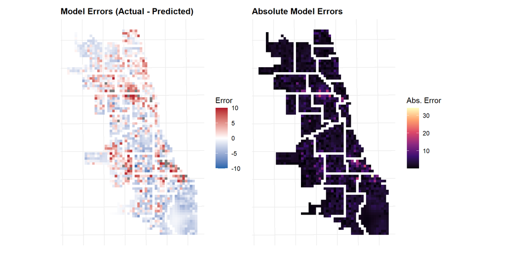

```r
# Calculate errors
fishnet <- fishnet %>%
  mutate(
    error_nb = countBurglaries - prediction_nb,
    error_kde = countBurglaries - prediction_kde,
    abs_error_nb = abs(error_nb),
    abs_error_kde = abs(error_kde)
  )

# Map errors
p1 <- ggplot() +
  geom_sf(data = fishnet, aes(fill = error_nb), color = NA) +
  scale_fill_gradient2(
    name = "Error",
    low = "#2166ac", mid = "white", high = "#b2182b",
    midpoint = 0,
    limits = c(-10, 10)
  ) +
  labs(title = "Model Errors (Actual - Predicted)") +
  theme_crime()

p2 <- ggplot() +
  geom_sf(data = fishnet, aes(fill = abs_error_nb), color = NA) +
  scale_fill_viridis_c(name = "Abs. Error", option = "magma") +
  labs(title = "Absolute Model Errors") +
  theme_crime()

p1 + p2
```

**ImportantAssessing Model Performance**

- **Spatial pattern of residuals:** The left panel shows both overpredictions (in blue) and underpredictions (in red), suggesting that the model’s performance varies systematically across neighborhoods rather than being random.
- **Magnitude of errors:** The right panel shows absolute errors concentrated in similar regions, confirming that prediction accuracy is uneven across thecity. Some fishnet grid cells exhibiting substantially higher deviations between observed and predicted values.
- **Error clustering:** Clusters of higher errors appear on the South and West Sides, which is also where crime data for 2017 is clustered as shown in earlier maps. This is a key limitation of the model – possibly due to unobserved local factors or data quality issues in these areas.

# Part 9: Summary Statistics

```r
# Create nice summary table
model_summary <- broom::tidy(final_model, exponentiate = TRUE) %>%
  mutate(
    across(where(is.numeric), ~round(., 3))
  )

model_summary %>%
  kable(
    caption = "Final Negative Binomial Model Coefficients (Exponentiated)",
    col.names = c("Variable", "Rate Ratio", "Std. Error", "Z", "P-Value")
  ) %>%
  kable_styling(bootstrap_options = c("striped", "hover")) %>%
  footnote(
    general = "Rate ratios > 1 indicate positive association with burglary counts."
  )
```

Final Negative Binomial Model Coefficients (Exponentiated)

| Variable | Rate Ratio | Std. Error | Z | P-Value |
| --- | --- | --- | --- | --- |
| (Intercept) | 5.269 | 0.057 | 29.041 | 0 |
| abandoned_bldg | 1.051 | 0.009 | 5.268 | 0 |
| abandoned_bldg.nn | 0.999 | 0.000 | -12.285 | 0 |
| dist_to_hotspot | 1.000 | 0.000 | 3.837 | 0 |

Note:  
Rate ratios > 1 indicate positive association with burglary counts.

## Key Findings Checklist

**Technical Performance:**

- Cross-validation MAE: 2.69
- Model vs. KDE: KDE performed better than the final negative binomial model as it produced a lower MAE and RMSE than the model based on abandoned and vacant buildings

**Spatial Patterns:**

- Burglaries are clustered as clearly visualized in the Kernel Density Estimation Baseline
- Hot spots are largely located in the West Side and South Side neighborhoods

**Model Limitations:**